# Final Project: NYC Arrests Prediction

### 6.3.1 Ridge Sensitivity Analysis - Subset

We then run our ridge regression over our subset matrix.

```r
# run ridge regression on subset predictors
ridge_subset <- cv.glmnet(x = X_train_subset, y = y_train, alpha = 0, family = "binomial", type.measure = "auc")

ridge_lambda_min_subset <- ridge_subset$lambda.min
cat("Optimal lambda for ridge (subset):", ridge_lambda_min_subset, "\n")
```

```
## Optimal lambda for ridge (subset): 0.01264539
```

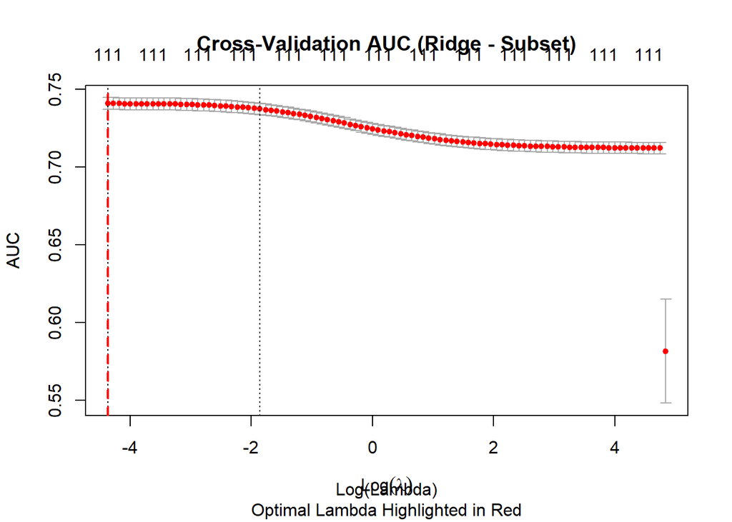

```r
# plot auc against log lambda
plot(ridge_subset)
abline(v = log(ridge_lambda_min_subset), col = "red", lwd = 2, lty = 2)
title(main = "Cross-Validation AUC (Ridge - Subset)",
      sub = "Optimal Lambda Highlighted in Red",
      xlab = "Log(Lambda)", ylab = "AUC")
```

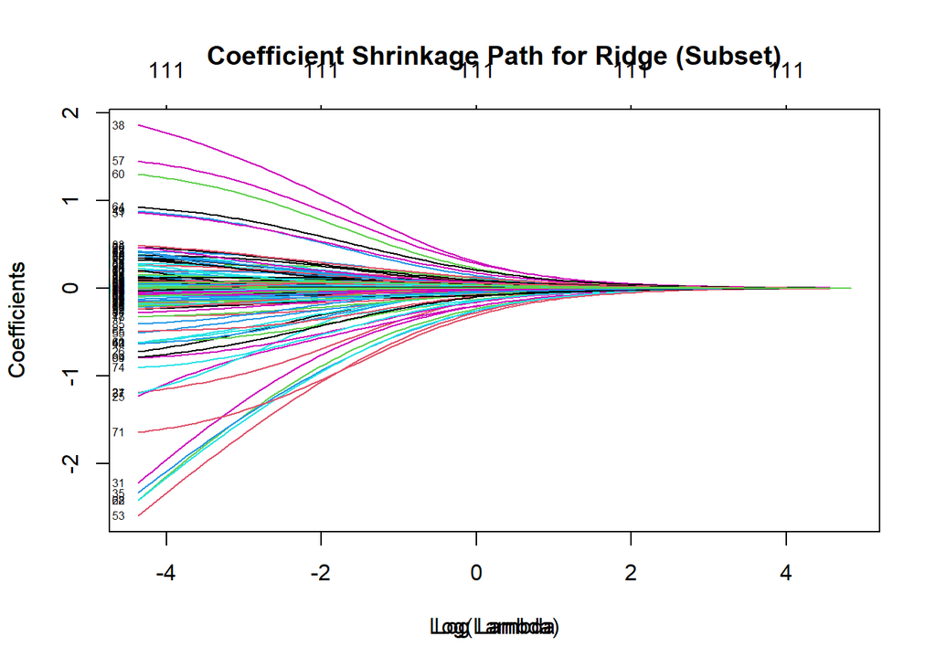

```r
# plot coefficients
plot(ridge_subset$glmnet.fit, xvar = "lambda", label = TRUE)
title(main = "Coefficient Shrinkage Path for Ridge (Subset)",
      xlab = "Log(Lambda)", ylab = "Coefficients")
```

```
## # A tibble: 4 × 4
## # Groups:   Predicted [2]
##   True  Predicted  Freq Predicted_pct
##   <fct> <fct>     <int>         <dbl>
## 1 0     0          2221         0.772
## 2 1     0           657         0.228
## 3 0     1           244         0.344
## 4 1     1           465         0.656
```

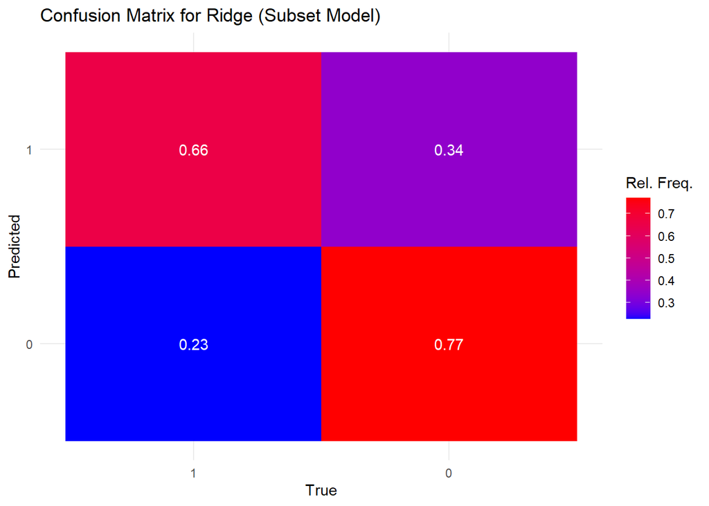

```r
# get fitted probabilities
ridge_predict_subset <- as.numeric(predict(ridge_subset, s = ridge_lambda_min_subset, X_test_subset, type = "response"))

# add variable for predicted classes
ridge_y_hat_subset <- ifelse(ridge_predict_subset > 0.5, 1, 0)

# plot confusion matrix for ridge subset regression out of sample
generate_cm(y_test, ridge_y_hat_subset, "Confusion Matrix for Ridge (Subset Model)")
```

```r
# compute roc object for subset ridge model
ridge_roc_subset <- roc(response = y_test, predictor = ridge_predict_subset, quiet = TRUE)
ridge_auc_subset <- round(auc(ridge_roc_subset), 4)
cat("AUC for the Ridge (subset) model:", ridge_auc_subset, "\n")
```

```
## AUC for the Ridge (subset) model: 0.775
```

However, the differences between models are still very modest so they suggest they have similar predictive capabilities.

## 6.4 Tuned Elastic Net

Now we implement a tuned elastic net regression model, choosing to tune for both optimal lambda and alpha to get the optimal weighting between ridge and LASSO models. For this we use our validation data sample as mentioned earlier.

We loop over a defined set of alpha values from 0 to 1, at spacings of 0.1, due to computational efficiency. We then use the validation sample and pick the alpha lambda combination which yields the highest AUC. We then use the testing sample to compute the confusion matrix and AUC for the optimal model.

For computational efficiency, we only run the elastic net regression on the subset:

```r
# Define alpha values for grid search
alpha_values <- seq(0, 1, by = 0.1)

# Initialize storage for results
results <- data.frame(alpha = alpha_values, auc = NA, optimal_lambda = NA)

# loop grid search
for (i in 1:nrow(results)) {
  alpha_i <- results$alpha[i]

  # train en model with cross-validation for the given alpha
  en_opt <- cv.glmnet(
    x = X_train_subset_final,
    y = y_train_final,
    alpha = alpha_i,
    family = "binomial",
    type.measure = "auc"
  )

  # get the best lambda for the current alpha
  en_opt_lambda_min <- en_opt$lambda.min

  # get fitted probabilities on the validation set using the best lambda and current alpha
  en_opt_predict_val <- as.numeric(predict(en_opt, s = en_opt_lambda_min, newx = X_val_subset, type = "response"))

  # compute roc and aucs of trained model in validation data
  en_opt_roc_val <- roc(response = as.numeric(y_val), predictor = en_opt_predict_val, quiet = TRUE)
  en_opt_auc_val <- auc(en_opt_roc_val)

  # add to storage vector
  results$auc[i] <- en_opt_auc_val
  results$optimal_lambda[i] <- en_opt_lambda_min
}

# identify the best alpha
best_params <- results[which.max(results$auc), ]
cat("Optimal alpha:", best_params$alpha, "\n")
```

```
## Optimal alpha: 0.3
```

```r
cat("Optimal lambda:", best_params$optimal_lambda, "\n")
```

```
## Optimal lambda: 0.02158539
```

```r
cat("Best AUC:", best_params$auc, "\n")
```

```
## Best AUC: 0.731679
```

```
## # A tibble: 4 × 4
## # Groups:   Predicted [2]
##   True  Predicted  Freq Predicted_pct
##   <fct> <fct>     <int>         <dbl>
## 1 0     0          2284         0.751
## 2 1     0           756         0.249
## 3 0     1           181         0.331
## 4 1     1           366         0.669
```

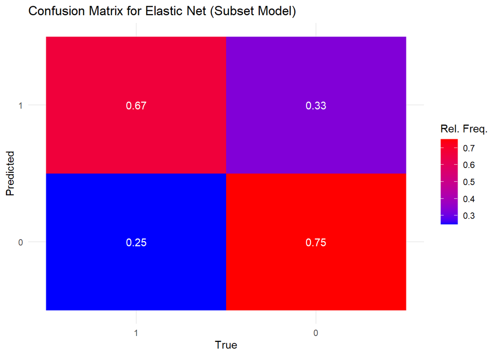

```r
# train the tuned elastic net model with best hyperparameters
en_opt <- glmnet(
  x = X_train_subset_final,
  y = y_train_final,
  alpha = best_params$alpha,
  lambda = best_params$optimal_lambda,
  family = "binomial"
)

# get fitted probabilities using trained model on test data
en_opt_predict <- as.numeric(predict(en_opt, s = best_params$optimal_lambda, newx = X_test_subset, type = "response"))

# add variable for predicted classes
en_opt_y_hat <- ifelse(en_opt_predict > 0.5, 1, 0)

# plot confusion matrix for tuned elastic net regression out of sample
generate_cm(y_test, en_opt_y_hat, "Confusion Matrix for Elastic Net (Subset Model)")
```

```r
# compute test ROC and AUC out of sample
en_opt_roc_subset <- roc(response = as.numeric(y_test), predictor = en_opt_predict, quiet = TRUE)
en_opt_auc_subset <- auc(en_opt_roc_subset)
cat("Test AUC for Tuned Elastic Net model:", en_opt_auc_subset, "\n")
```

```
## Test AUC for Tuned Elastic Net model: 0.7708506
```

This is likely due to how we split the training dataset into a training and validation set, and we then run that on the test data. This means that the elastic net model only has half as much training data than our previous models. The fact that it performs similarly well, despite only having half the data, suggests that it would potentially perform even better if it used the same training data as the previous models.

## 6.5 Random Forest

Next, we implement the random forest algorithm to deal with potential non-linearities in the data, as well as the sparsity that the shrinkage regressions tackle.

We do this on the subset of the data as for similar reasons as with our previous regressions. Like with the elastic net, regression we only run the subset for the random forest for computational efficiency since we have two-way hyperparametre optimisation. This also means we use the three-way split of the data into a training sample, validation sample, and testing sample, like with the elastic net.

We tune the maximum number features of the tree first. We want to refine the maximum number of features to simplify the model. We choose the maximum number of features to loop over as $m = 20$ and $ntree \in {50, 100, 150}$, as they provide a good spread of values for a parametre optimisation grid search, whilst preserving computational efficiency.

We run the random forest regression here:

```r
# Initialize parameter grid for grid search
ntrees <- seq(50, 150, 50)  # range of trees to tune over
max_features_range <- 1:20  # Range of mtry  (max features) to tune over

# initialize storage for accuracy metrics
results <- expand.grid(ntree = ntrees, mtry = max_features_range)

dim(results)
```

```
## [1] 60  2
```

```r
results$train_acc <- NA
results$test_acc <- NA
results$oob_acc <- NA

# tune
for (i in 1:nrow(results)) {
  ntrees_i <- results$ntree[i]
  mtry_i <- results$mtry[i]

  # train rf model using training data and current iteration of mtry and ntree
  rf <- randomForest(
    x = X_train_subset_final,
    y = factor(y_train_final),
    mtry = mtry_i,
    ntree = ntrees_i
  )

  # use trained model to predict y in validation data
  y_pred_val <- predict(rf, X_val_subset)

  # get trained model predictions of y in training data
  y_pred_train <- rf$predicted

  # compute out of bag accuracy measure
  results$oob_acc[i] <- 1 - rf$err.rate[ntrees_i, "OOB"]

  # compute training accuracy measure
  results$train_acc[i] <- mean(y_train_final == as.numeric(levels(y_pred_train)[y_pred_train]))

  # compute "test" - validation - accuracy
  results$test_acc[i] <- mean(y_val == as.numeric(levels(y_pred_val)[y_pred_val]))
}

# identify the optimal parameters
best_params <- results[which.max(results$test_acc), ]
cat("Optimal ntree:", best_params$ntree, "\n")
```

```
## Optimal ntree: 100
```

```r
cat("Optimal mtry:", best_params$mtry, "\n")
```

```
## Optimal mtry: 18
```

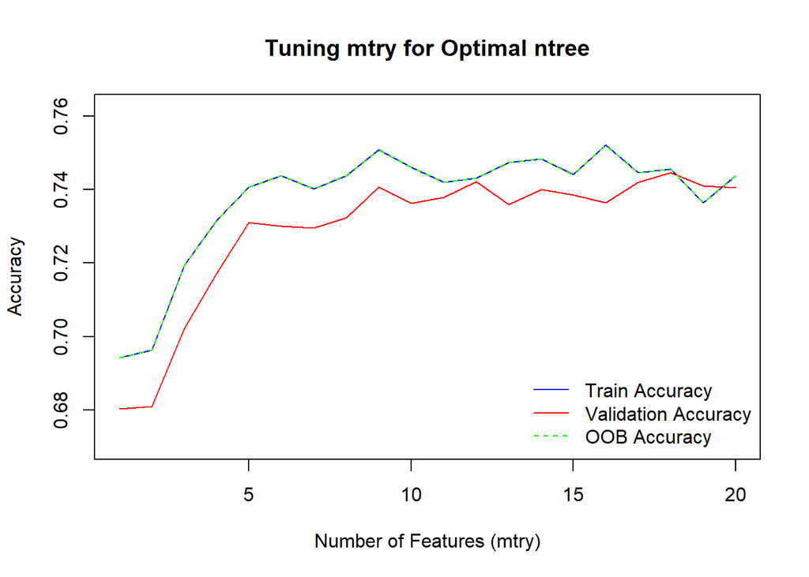

```r
# define accuracy metrics and y-axis range for tuning plot
accuracy_metrics <- results[results$ntree == best_params$ntree, ]
y_range <- range(c(accuracy_metrics$train_acc, accuracy_metrics$test_acc, accuracy_metrics$oob_acc)) + c(-0.01, 0.01)

# plot train, validation, and OOB accuracy for optimal ntree as mtry varies
plot(
  accuracy_metrics$mtry, accuracy_metrics$train_acc,
  type = 'l', col = 'blue', ylim = y_range,
  main = 'Tuning mtry for Optimal ntree',
  xlab = 'Number of Features (mtry)', ylab = 'Accuracy'
)
lines(accuracy_metrics$mtry, accuracy_metrics$test_acc, col = 'red')
lines(accuracy_metrics$mtry, accuracy_metrics$oob_acc, col = 'green', lty = 2)
legend('bottomright',
       legend = c('Train Accuracy', 'Validation Accuracy', 'OOB Accuracy'),
       col = c('blue', 'red', 'green'), lty = c(1, 1, 2), bty = 'n')
```

```r
# given optimal parameters, train using training data to get tuned model
RFTuned <- randomForest(
  x = X_train_subset_final,
  y = factor(y_train_final),
  mtry = best_params$mtry,
  ntree = best_params$ntree
)

# using model trained with optimal parameters, predict with TEST data
RFPred <- predict(RFTuned, newdata = X_test_subset)

# compute associated relevant fitted probabilities
RFProb <- predict(RFTuned, newdata = X_test_subset, type = "prob")

# compute test roc and auc of tuned model
RF_roc <- roc(response = factor(y_test), predictor = RFProb[, 2], levels = c(0, 1), quiet = TRUE)
RF_auc <- round(auc(RF_roc), 4)
cat("Random Forest AUC (Subset):", RF_auc, "\n")
```

```
## Random Forest AUC (Subset): 0.7926
```

```r
# gen confusion matrix
generate_cm(
  true = y_test,
  predicted = RFPred,
  title = "Confusion Matrix for Random Forest (Subset)"
)
```

```
## # A tibble: 4 × 4
## # Groups:   Predicted [2]
##   True  Predicted  Freq Predicted_pct
##   <fct> <fct>     <int>         <dbl>
## 1 0     0          2277         0.774
## 2 1     0           664         0.226
## 3 0     1           188         0.291
## 4 1     1           458         0.709
```

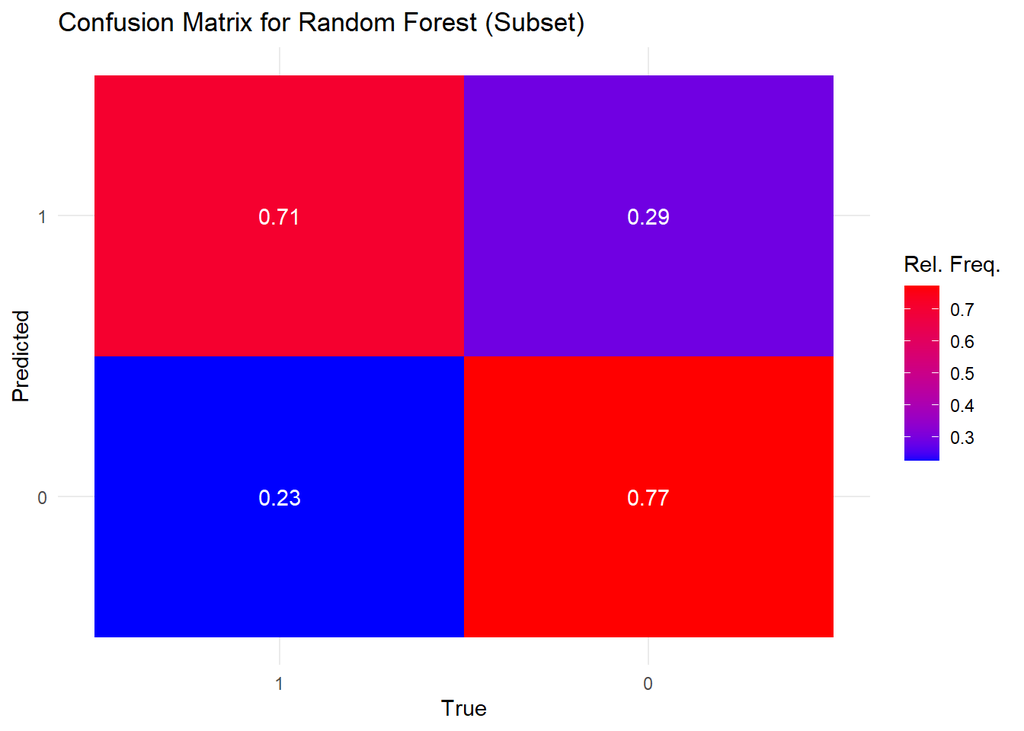

We find an optimal tree length of 100 and an optimal feature inclusion of 18.

This suggests that the random forest model is able to deal with non-linearities in the data that the linear classification models we used previously are not able to deal with. This could be aspects like interaction effects which we do not account for. Police officers may look for patterns in behaviour when arresting someone, for example they may be more likely to arrest tall, heavy, and young black men.

# 7 Results - Comparison

Finally we want to visualise the comparisons of the ROC curves and AUCs for all our regressions.

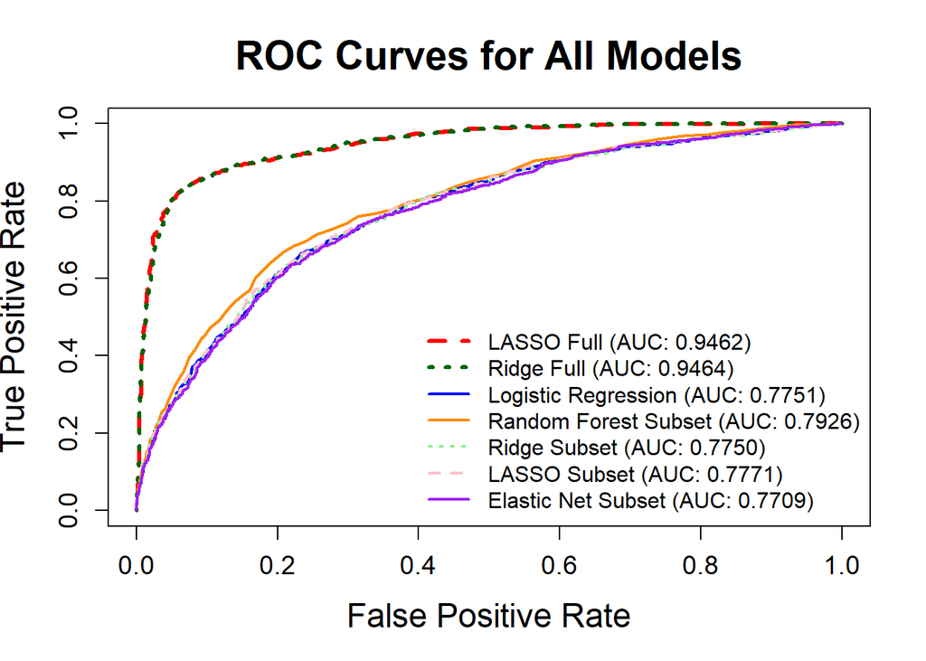

```r
# function to plot ROC curves for multiple models
plot_multiple_roc <- function(roc_list, labels, colors, lwd_list, lty_list, main_title) {
  # Plot the first model as the base plot
  plot(
    x = 1 - roc_list[[1]]$specificities,
    y = roc_list[[1]]$sensitivities,
    type = "l",
    col = colors[1],
    lwd = lwd_list[1],
    lty = lty_list[1],
    xlim = c(0, 1),
    ylim = c(0, 1),
    main = main_title,
    xlab = "False Positive Rate",
    ylab = "True Positive Rate",
    cex.lab = 1.5,
    cex.main = 1.8,
    cex.axis = 1.2
  )

  # Add the remaining ROC curves
  for (i in 2:length(roc_list)) {
    lines(
      x = 1 - roc_list[[i]]$specificities,
      y = roc_list[[i]]$sensitivities,
      col = colors[i],
      lwd = lwd_list[i],
      lty = lty_list[i]
    )
  }

  # Add legend
  legend(
    "bottomright",
    legend = labels,
    col = colors,
    lwd = lwd_list,
    lty = lty_list,
    bty = "n"
  )
}

# create list of rocs and associated labels and colors
roc_list <- list(lasso_roc_full, ridge_roc_full, logit_roc, RF_roc, ridge_roc_subset, lasso_roc_subset, en_opt_roc_subset)

labels <- c(
  sprintf("LASSO Full (AUC: %.4f)", lasso_auc_full),
  sprintf("Ridge Full (AUC: %.4f)", ridge_auc_full),
  sprintf("Logistic Regression (AUC: %.4f)", logit_auc),
  sprintf("Random Forest Subset (AUC: %.4f)", RF_auc),
  sprintf("Ridge Subset (AUC: %.4f)", ridge_auc_subset),
  sprintf("LASSO Subset (AUC: %.4f)", lasso_auc_subset),
  sprintf("Elastic Net Subset (AUC: %.4f)", en_opt_auc_subset)
)

colors <- c("red", "darkgreen", "blue", "darkorange", "lightgreen", "pink", "purple")
lwd_list <- c(3, 3, 2, 2, 2, 2, 2)
lty_list <- c(2, 3, 1, 1, 3, 2, 1)


#call
plot_multiple_roc(
  roc_list = roc_list,
  labels = labels,
  colors = colors,
  lwd_list = lwd_list,
  lty_list = lty_list,
  main_title = "ROC Curves for All Models"
)
```

```r
# make and print sorted table of AUCs
auc_table <- data.frame(
  Model = c(
    "Logistic Regression",
    "LASSO Full",
    "LASSO Subset",
    "Ridge Full",
    "Ridge Subset",
    "Elastic Net Subset",
    "Random Forest Subset"
  ),
  AUC = c(
    logit_auc,
    lasso_auc_full,
    lasso_auc_subset,
    ridge_auc_full,
    ridge_auc_subset,
    en_opt_auc_subset,
    RF_auc
  )
)

auc_table <- auc_table %>%
  arrange(desc(AUC))

print(auc_table)
```

```
##                  Model       AUC
## 1           Ridge Full 0.9464000
## 2           LASSO Full 0.9462000
## 3 Random Forest Subset 0.7926000
## 4         LASSO Subset 0.7771000
## 5  Logistic Regression 0.7751000
## 6         Ridge Subset 0.7750000
## 7   Elastic Net Subset 0.7708506
```

As discussed before, we see how the two full shrinkage regressions perform exceptionally well out of sample, however, this is likely be due to potential results engineering due to some variables being potentially taking place after an arrest. The other ROC curves seem to otherwise be very similar, however, the ROC curve for the random forest estimation clearly stands out as having a better out of sample fit, compared to its peers.

## 7.1 Variable Importance

We then consider the most important variables in each of the logit and shrinkage regressions. An important point to note is that we scale the importance of these variables, so that the most important variable has an importance of 1, and the least important 0. Therefore, a scaled importance of 1 is **NOT** indicative of the problem of multicollinearity (not perfect multicollinearity) or overfitting, it is an indication of relative importance.

We show our results here:

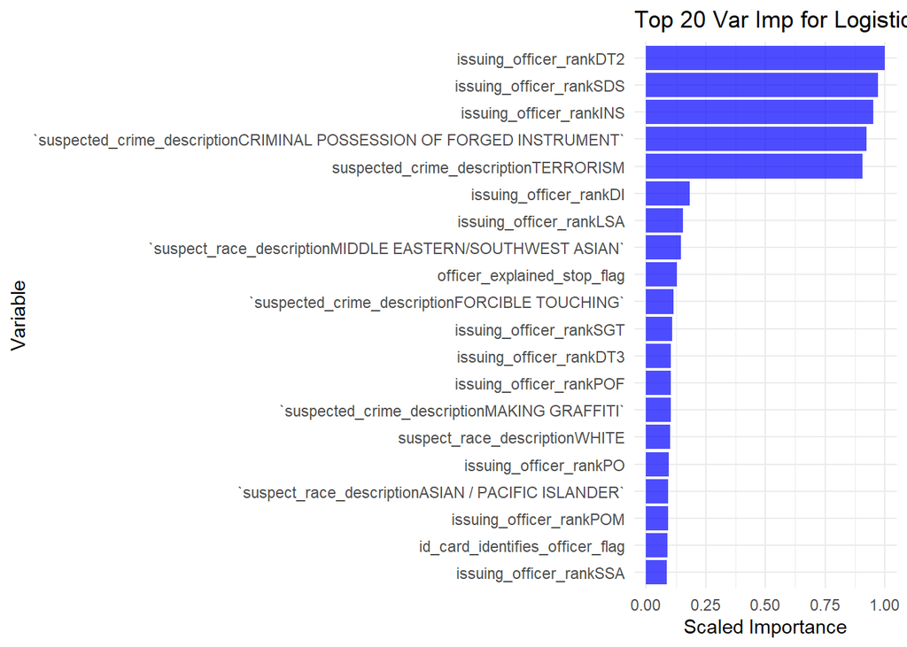

```r
# Function to compute and plot variable importance
compute_variable_importance <- function(coefficients, model_name, top_n = 20) {
  importance_df <- data.frame(
    Variable = names(coefficients),
    Scaled_Importance = abs(coefficients) / max(abs(coefficients), na.rm = TRUE)
  ) %>%
    filter(Scaled_Importance > 0) %>%
    arrange(desc(Scaled_Importance)) %>%
    slice(1:top_n)

  ggplot(importance_df, aes(x = reorder(Variable, Scaled_Importance), y = Scaled_Importance)) +
    geom_bar(stat = "identity", fill = "blue", alpha = 0.7) +
    coord_flip() +
    labs(
      title = paste("Top", top_n, "Var Imp for", model_name),
      x = "Variable",
      y = "Scaled Importance"
    ) +
    theme_minimal()
}

# 1. Logistic Regression
logit_coeff <- coef(logit)
logit_coeff <- logit_coeff[-1]
logit_plot <- compute_variable_importance(logit_coeff, "Logistic Regression")
print(logit_plot)
```

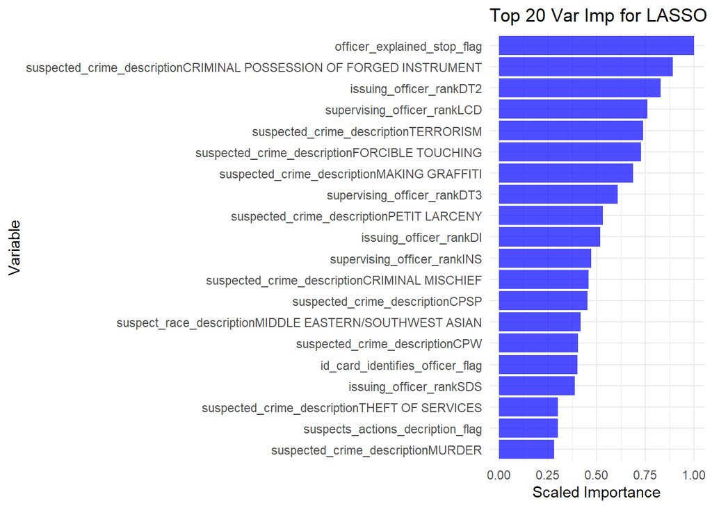

```r
# 2. LASSO Subset
lasso_subset_coeff <- as.numeric(coef(lasso_subset, s = lasso_lambda_min_subset))
names(lasso_subset_coeff) <- rownames(coef(lasso_subset, s = lasso_lambda_min_subset))
lasso_subset_coeff <- lasso_subset_coeff[-1]
lasso_plot <- compute_variable_importance(lasso_subset_coeff, "LASSO Subset")
print(lasso_plot)
```

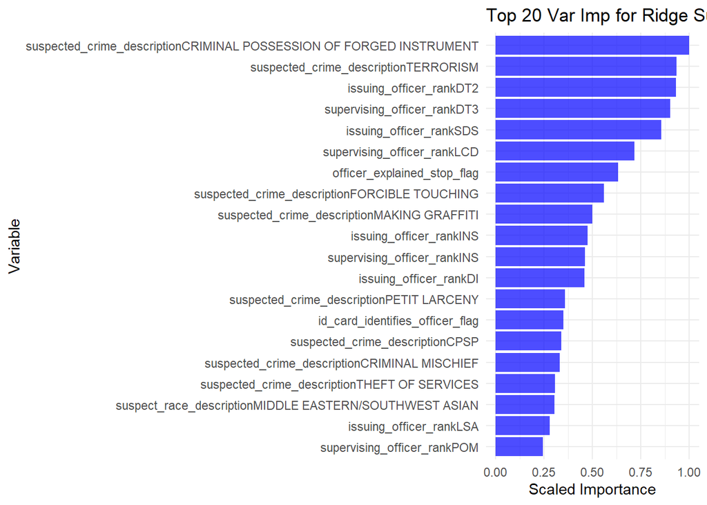

```r
# 3. Ridge Subset
ridge_subset_coeff <- as.numeric(coef(ridge_subset, s = ridge_lambda_min_subset))
names(ridge_subset_coeff) <- rownames(coef(ridge_subset, s = ridge_lambda_min_subset))
ridge_subset_coeff <- ridge_subset_coeff[-1]
ridge_plot <- compute_variable_importance(ridge_subset_coeff, "Ridge Subset")
print(ridge_plot)
```

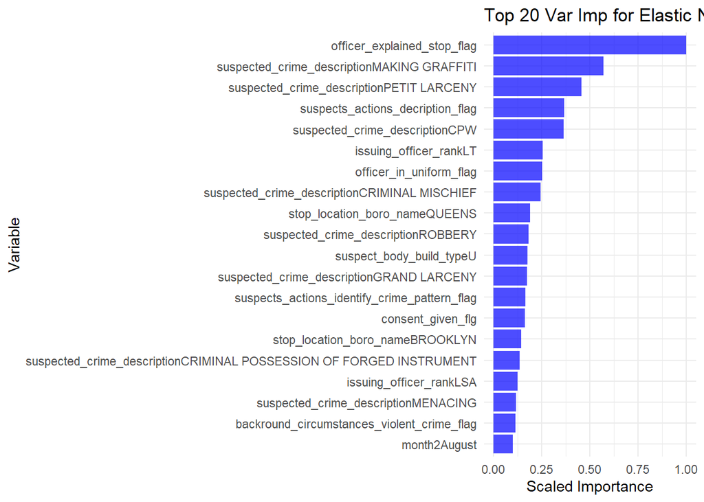

```r
# 4. Elastic Net Subset

en_subset_coeff <- as.numeric(coef(en_opt, s = best_params$optimal_lambda))
names(en_subset_coeff) <- rownames(coef(en_opt, s = best_params$optimal_lambda))
en_subset_coeff <- en_subset_coeff[-1]
en_plot <- compute_variable_importance(en_subset_coeff, "Elastic Net Subset")
print(en_plot)
```

We see that the logistic curve classifies dummies indicating the rank of the officer conducting the stop as the most important variables in predicting arrest, with certain suspected crimes also being highly predictive. The latter makes sense, as for it is easy to understand why on certain crimes like terrorism, the police would err on the side of caution and arrest a stopped subject. It is also easy to understand why certain very specific crimes, like criminal posession of a forges instrument, might only lead to stops when the threshhold for arrest has already been surpassed.

On the side of the shrinkage estimators a couple key factors show up in each of the three types of predictors. The `officer_explained_stop_flag` is a very high predictor and it suggests that an officer explaining why a suspect has been stopped means there is good evidence for the suspect to be arrested and the officer is following protocol to avoid potential legal complications. We also see certain crime and officer rank dummies featuring highly. Their presence would be explained by the same explanation as with the logit estimator.

Next we consider the most important variables in the random forest estimation:

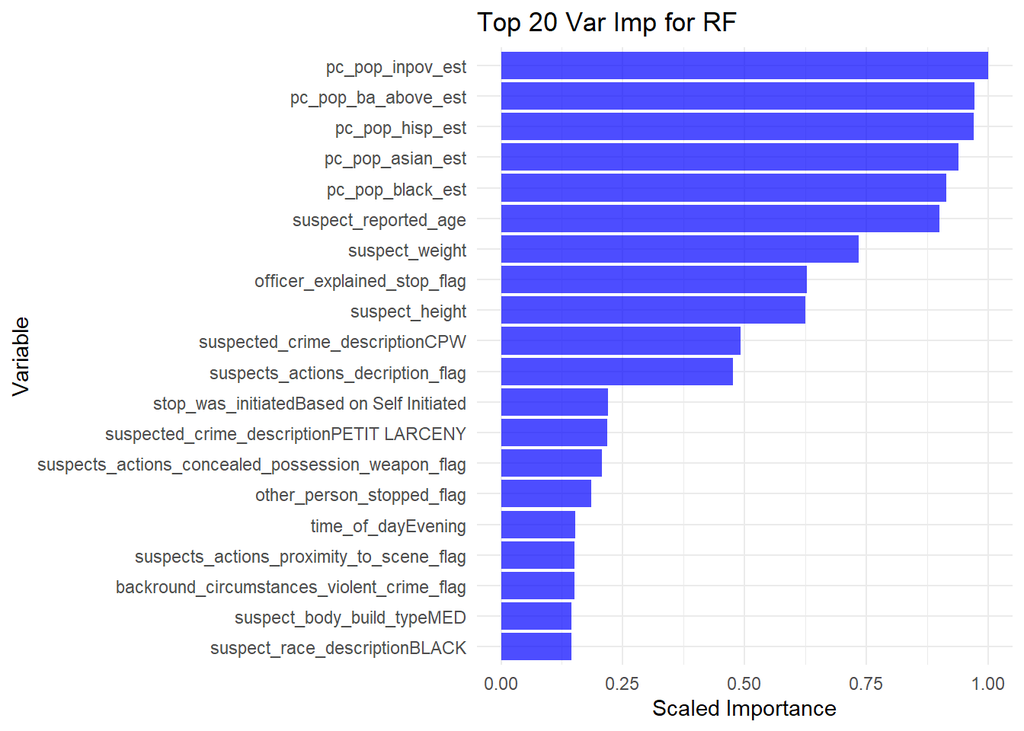

```r
# Extract Random Forest importance
rf_importance_subset <- data.frame(
  Variable = rownames(RFTuned$importance),
  Scaled_Importance = RFTuned$importance[, "MeanDecreaseGini"] / max(RFTuned$importance[, "MeanDecreaseGini"], na.rm = TRUE)
)
rf_importance_subset <- rf_importance_subset %>%
  arrange(desc(Scaled_Importance))

# plot rf variable importance - top 20
ggplot(rf_importance_subset %>% arrange(desc(Scaled_Importance)) %>% slice(1:20),
       aes(x = reorder(Variable, Scaled_Importance), y = Scaled_Importance)) +
  geom_bar(stat = "identity", fill = "blue", alpha = 0.7) +
  coord_flip() +
  labs(title = "Top 20 Var Imp for RF",
       x = "Variable",
       y = "Scaled Importance") +
  theme_minimal()
```

In the random forest model, we still see the `officer_explained_stop_flag` as being relatively important, along with certain suspected crime dummies, however, these features are a lot less important than in the linear models we explored earlier. What we see here as being most important are demographic dummies describing a neighbourhood’s racial composition and level of education. This suggests that the percentage of a neighbourhood in poverty, with a Bachelor’s degree, or who are Hispanic are the best predictors of arrest. This is more supportive of the initial assessment that demographic characteristics play an important role in how the police police different neighbourhoods. This would be supportive of the suggestion that the NYPD have some level of racial bias in how they approach these stops.

# 8 Conclusion

Our analysis of the NYPD’s stop-and-frisk programme in 2023 indicates that the prediction of whether a police officer makes an arrest is best explained by a random forest. Our random forest model, performs modestly but decisively better than both the shrinkage and logit estimators. This suggests that the process by which a stop turns into an arrest is both modestly sparse and non-linear, which is why the random forest is able to perform better.

Our initial exploration of the dataset’s descriptive statistics and the random forest model indicates that racial bias plays an important role both in how the police, approach the stop-and-frisk programme and in how they make their arrests. There appears to be a two-way effect. Our exploratory analysis suggests that the police have a more intense present in poorer neighbourhoods disproportionately inhabited by ethnic minorities. Therefore, the random forest suggests that when they make a stop in a more affluent and educated neighbourhood there is more reason to arrest the person. On the other hand the high predictive importance of racial and income components in the random forest indicates that the police are both more present in these neighbourhoods and more willing to arrest stopped individuals in them. These individuals are dispropotionately poorer ethnic minorities.

A potential extension to this model would be to attempt to fit the “full” regression model to both the random forest and the tuned elastic net. This would be viable with more computing power, and it would be a useful extension to see whether the random forest was robust to adding new variables. We could also attempt to fit the models on previous years stop-and-frisk data to see if their out-of-sample goodness of fit extended to other years’ data.

Despite, having a large dataset of over 10000 observations, even after our dataset undergoes significant cleaning and feature engineering, our dataset still exhibits a high degree of granularity due to the large number of predictors. Therefore, it is unsurprising that some of these predictors exhibit little to no variation. We can see this in the chart showing the percentage of “nulls” in each feature, since many of these “nulls” are actually zeros.This lack of variation is also clear in some of the spacial features, as we can see that not all localities in the map have an arrest percentage to report in our exploratory analysis. Whilst, we drop multicollinear variables for our logit model, and shrinkage estimators and the random forest are designed to be more robust to a lack of variation in features, there could still be some issues with overfitting due to the sheer number of features with limited variation.

[^1]: In the raw data, the flag’s entries are actually `"Y"` and `"N"`, but we clean this.
[^2]: Run time increases significantly if we tune elastic net and random forest for the full set of predictors and the subset of predictors.